# Prop 40, supporting side: the reproduction

Boll, Saez and Zucman (2026) and the GGSS expert report, reproduced step by step from the authors’ August 2026 workbook

Published

September 23, 2026

Supporting side of California Proposition 40: Open Output (the explorer) · Open Analysis: Report (here) and Slides · Open Materials · Overview

**setup: every number below is read from the targets store**

```r
library(targets)
library(gt)
library(ggplot2)
# The report never recomputes or retypes a result: it reads the targets that
# the pipeline built (supporting-analysis/_targets.R). The R/ functions are
# sourced only to compare against the workbook's cached cells below.
invisible(lapply(list.files("../R", pattern = "[.]R$", full.names = TRUE), source))
STORE <- normalizePath("../_targets")
tr <- function(name) targets::tar_read_raw(name, store = STORE)

t5   <- tr("tab5_r")
inp  <- tr("site_scoring_inputs")
grid <- tr("site_grid")
par  <- tr("pareto_summary")
agg  <- tr("data_sec_agg_r")
laf  <- tr("fig8_laffer_r")
ins  <- tr("site_inputs")
stopifnot(identical(inp$vintage, "august"))

bn  <- function(x, d = 1) formatC(x, format = "f", digits = d, big.mark = ",")
usd <- function(x, d = 1) paste0("\\$", bn(x, d), " billion")
pct <- function(x, d = 1) paste0(formatC(100 * x, format = "f", digits = d), "%")
show <- function(df) knitr::kable(df, format = "html", escape = TRUE,
                                  table.attr = 'class="table table-sm"')
```

## Introduction

[figure not shown]

California’s Proposition 40, the Billionaire Tax Act, would levy a one-time 5% tax on the net worth of California’s billionaires, paid 1% a year over five years. Two documents carry the supporting side’s revenue estimate, and this report reproduces both:

1. **Boll, Saez and Zucman (BSZ)**, *California Billionaires: Wealth, Taxes, and Wealth Tax Revenue Estimates*, NBER Working Paper 35218, August 2026 revision, and its supplementary Excel workbook. Table 5, row 1 scores the tax at **$103.8 billion**.
2. **Galle, Gamage, Saez and Shanske (GGSS)**, *Expert Report on Proposition 40*, updated 20 July 2026. It cites **$100 billion**, and says on p.4 where that comes from: “Factoring in 10% of tax avoidance and evasion leads to a scoring of $104 billion that we round to $100 billion for simplicity.” So the GGSS number is the BSZ row-1 computation, rounded. Reproducing one reproduces the other.

This report is part of an Open Policy Analysis of the supporting side:

- **Open Output**: the explorer, where the assumptions move and the revenue follows
- **Open Analysis**: this document, and the slide deck
- **Open Materials**: the materials page, every script, test and data file

**The preferred estimate** is Table 5, row 1: $103.8 billion of one-time wealth tax revenue, with $3.7 billion of extra state income tax from asset sales and an income tax loss of $0.15 billion a year. It is the benchmark both documents lead with, and the one the campaign cites. Rows 2 to 4 of Table 5 are the authors’ own sensitivity checks; this report reproduces them and the explorer shows them next to the preferred row, but none of them replaces it. That follows the project’s pre-specified output (`PLAN.md`, “Pre-specified output”), fixed before any result was seen: the strongest version of each side, its two documents side by side.

**What “reproduced” means here.** The pipeline re-derives every formula cell of the authors’ workbook in R and checks each against the workbook’s own cached value. It does not re-collect the raw data: the Forbes wealth figures, the tax statistics and the SEC filings enter as the workbook records them. So the reproduction shows that the arithmetic from those inputs to the published tables is what the paper says it is. It does not show that the inputs are right.

### How to read this report

Text in blockquotes is quoted from the paper. Everything else is ours. Page numbers are **PDF pages** of the August 2026 working paper; the printed folio runs two lower in the main text. Every number in running text is computed when this page is rendered, from the pipeline’s stored results (open any “code” fold to see which one). Tables and figures are the pipeline’s own `gt` and `ggplot2` objects. The figures keep the May 2026 numbering the pipeline was first built against; where August renumbered, the text says so.

### Notation, in one place

| Symbol | Meaning | Value in row 1 |
| --- | --- | --- |
| $\tau$ | wealth tax rate (one time) | 5% |
| $W_0$ | wealth of California billionaires on 1 July 2026 | $2,307 billion |
| $n_0$ | number of those billionaires | 250 |
| $\alpha$ | share of wealth lost to avoidance and evasion | 10% |
| $m$ | share of that avoidance that is people leaving the state | 50% |
| $s$ | share of the tax paid by selling assets | 1/3 |
| $g$ | share of a sale’s price that is a taxable gain | 80% |
| $t_{cg}$ | top California tax rate on gains | 13.3% |
| $C$ | California income tax billionaires pay per year, 2019-2025 average | $3.06 billion |

# II. The wealth of California billionaires

## A. Short-run growth: Table 1 Panel A and Figure 1

> Table 1 Panel A provides basic statistics on California billionaires in recent years. (BSZ PDF p.5)

**What is computed.** For each year, total billionaire wealth is the sum of the Forbes wealth of every California resident on the list,
$$W_t = \sum_{i \in \text{CA}_t} w_{i,t},$$
with Larry Ellison excluded throughout, because he left California before 2026. Growth is $g_t = W_t / W_{t-1} - 1$, and the “2023-2025” row is the cumulative $W_{2025}/W_{2022} - 1$. In plain words: add up the list, then compare years. The top-4 column adds Page, Brin, Zuckerberg and Huang from the workbook’s SEC-based panel. August added a “1 July 2026” row, and replaced the paper’s old denominator (California GDP) with California’s total adjusted gross income (AGI), the income reported on tax returns.

The 2025 count is 240 billionaires holding $2,055 billion, which is the paper’s own figure (“240 billionaires with total wealth of $2055 billion”, Appendix A). Getting there needed one correction to the workbook, described under What reproduces: four rows of the raw list were pasted twice.

**Table 1: tar_read(tab1_gt)**

```r
tr("tab1_gt")
```

Table 1. Wealth Growth of California Billionaires

| Year | # | Wealth | Growth | % public | Top 4 wealth | CA GDP | Wealth / GDP |
| --- | --- | --- | --- | --- | --- | --- | --- |
| A. Recent nominal wealth growth of CA billionaires |  |  |  |  |  |  |  |
| 2022 | 175 | 843 | — | 46.8% | 209 | 1,898 | 44.4% |
| 2023 | 187 | 1,157 | 37.4% | 58.1% | 399 | 1,946 | 59.5% |
| 2024 | 197 | 1,570 | 35.6% | 64.5% | 625 | 2,117 | 74.2% |
| 2025 | 240 | 2,055 | 30.9% | 65.2% | 882 | 2,230 | 92.1% |
| 2026 (July 1st) | 250 | 2,307 | 24.5% | 60.0% | 948 | 2,299 | 100.3% |
| Growth during 2023-2025 | — | 1 | — | — | 3 | 0 | — |
| B. Long-term real wealth growth: top .001% wealthiest CA families (2026 $) |  |  |  |  |  |  |  |
| 1982 | 118 | 49 | 41.3% | 1,184.1% | 614 | 51,900 | — |
| 2026 | 225 | 2,291 | 1,019.1% | 2,254.1% | 2,299 | 102,000 | — |
| Ratio 2025 to 1982 | 2 | 47 | 2,469.0% | 190.4% | 4 | 2 | — |
| Annualized growth | 0 | 0 | 7.6% | 1.5% | 0 | 0 | — |

**Notes:** Panel A illustrates the wealth growth of CA billionaires in 2022-2025. Panel B compares the top .0002% wealthiest CA families’ wealth in 1982 vs 2025, all in 2025 dollars. Source: Forbes RTB snapshots + SEC EDGAR.

The values in this table match the August workbook cell for cell, but some of the pipeline’s display labels still carry the May wording: the denominator column is headed “CA GDP” though it now holds AGI, Panel B’s ratio row says “2025” though the endpoint is 2026, and the note still says “.0002%” and “2025 dollars”. Appendix Table A1 has the same label drift. Listed under What reproduces.

> Figure 1 plots the trajectory of California’s billionaires’ total wealth (in nominal current dollars) at the end of years 2019 to 2025 and for July 1st, 2026. (BSZ PDF p.5)

**Figure 1: tar_read(fig1)**

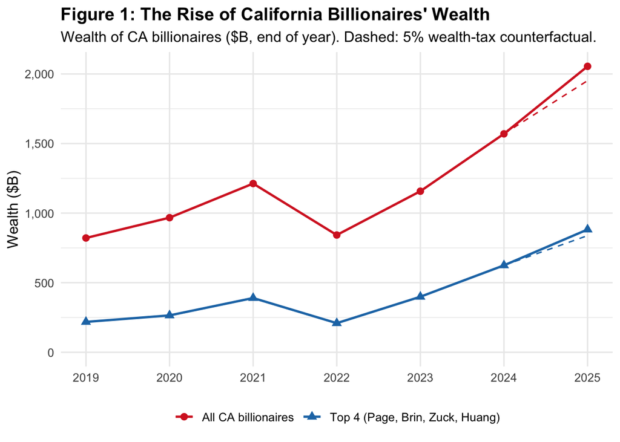

```r
tr("fig1")
```

In the August paper Figure 1 gains a Panel B, wealth by industry. The pipeline builds that chart as its “Appendix Figure A1”, the May numbering:

**industry chart: tar_read(fig_a1)**

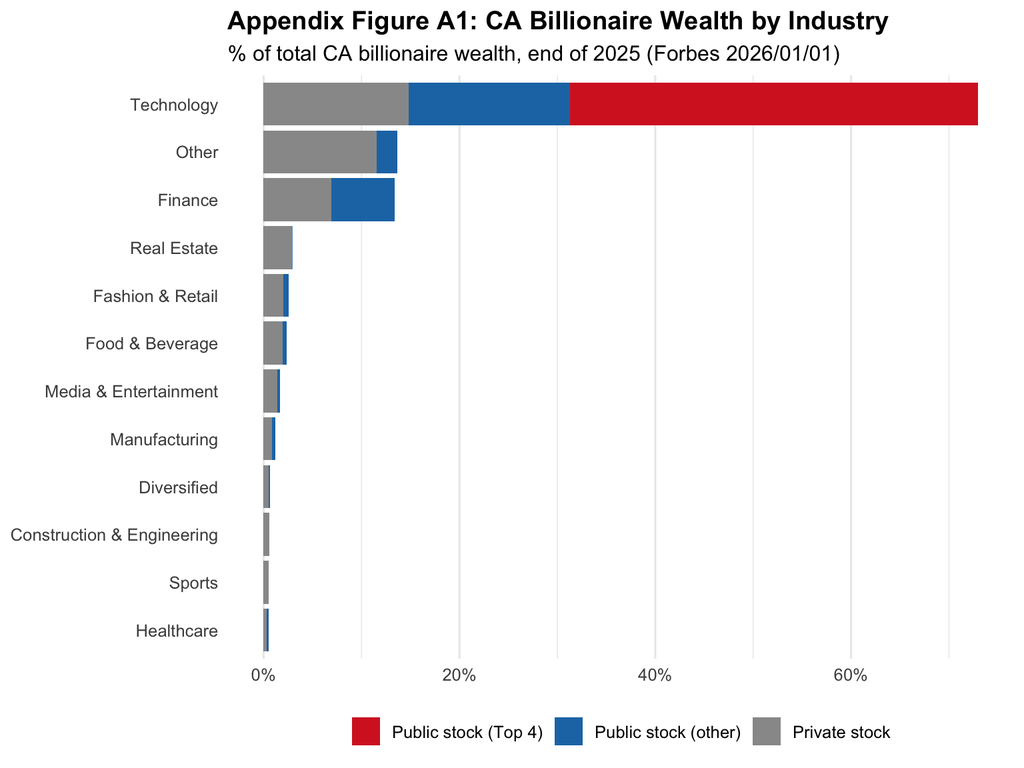

```r
tr("fig_a1")
```

## B. The long run: Table 1 Panel B and Figure 2

> Figure 2 depicts the longer time series. Panel A depicts the trajectory of top .001% wealth. (BSZ PDF p.8)

**What is computed.** Over forty years the number of billionaires grows with the population, so the paper follows a fixed *share* of families instead: in August, the top .001% (May used the top .0002%). Wealth is in real 2026 dollars. The comparison is with average income per family. The “annualized growth” row is the constant yearly rate that turns the 1982 value into the 2026 value:
$$\bar g = \left(\frac{X_{2026}}{X_{1982}}\right)^{1/44} - 1.$$

**Figure 2: tar_read(fig2)**

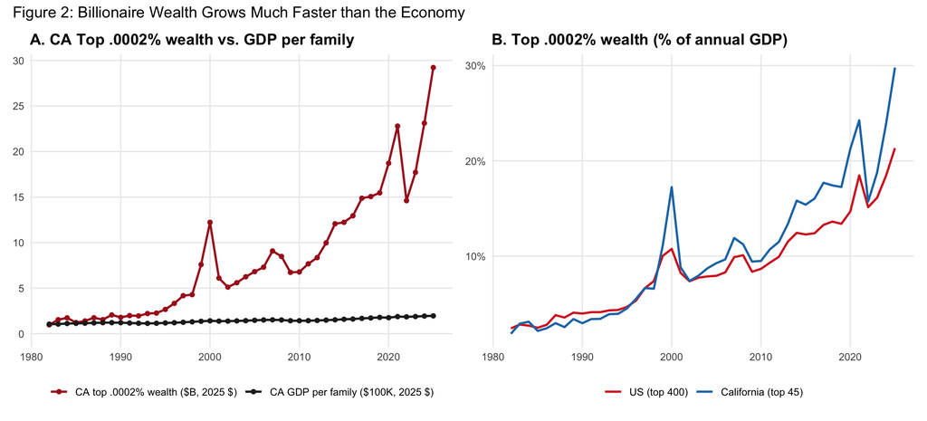

```r
tr("fig2")
```

# III. Taxes paid by California billionaires

## A. California income tax: Table 2, Figure 3 and Table 3

> For all California billionaires, we estimate the California income tax they pay using Franchise Tax Board (the California tax administration) tabulated statistics, a Pareto extrapolation, and an adjustment based on Federal tax data. (BSZ PDF p.10)

**Why an extrapolation.** Tax statistics are published by income bracket, not by name, and the top bracket holds thousands of filers, not the 240 billionaires. The paper assumes the top of the income distribution follows a Pareto law: above any cutoff $t$, average income is a constant multiple $b$ of $t$. From the top bracket’s filer count $n_t$ and total income $A_t$,
$$b = \frac{A_t / n_t}{t}, \qquad \hat t_N = t \left(\frac{n_t}{N}\right)^{1 - 1/b},$$
where $\hat t_N$ is the cutoff above which exactly $N$ filers sit ($N$ = the number of billionaires). Their average income is $b\,\hat t_N$, and applying the bracket’s average tax rate gives the tax the top $N$ *earners* pay.

**From top earners to top wealth holders.** Billionaires are not the top earners: the paper cites Balkir et al. (2025) and the Survey of Consumer Finances for top wealth holders’ income being about half of top earners’ income ($\theta = 0.5$), plus a small correction for the extrapolation overshooting on US data where the answer is known. The result is the “all California billionaires” column of Table 2. Its 2019-2025 average, $3.06 billion a year, is the $C$ that Table 5 uses below.

The top-4 columns need no extrapolation: the workbook computes each person’s income tax from their SEC filings (stock sales, dividends, option exercises).

**Table 2: tar_read(tab2_gt)**

```r
tr("tab2_gt")
```

Table 2. California Income Tax Paid by California Billionaires

| Year | All California Billionaires Wealth ($B) | All California Billionaires Est. CA inc. tax ($B) | All California Billionaires Tax / wealth | Top 4 (Page, Brin, Zuckerberg, Huang) on Company Wealth Company wealth ($B) | Top 4 (Page, Brin, Zuckerberg, Huang) on Company Wealth Est. CA inc. tax ($B) | Top 4 (Page, Brin, Zuckerberg, Huang) on Company Wealth Tax / wealth |
| --- | --- | --- | --- | --- | --- | --- |
| 2019 | 821 | 1.99 | 0.242% | 184 | 0.03 | 0.018% |
| 2020 | 967 | 2.77 | 0.286% | 247 | 0.06 | 0.022% |
| 2021 | 1,212 | 4.50 | 0.371% | 365 | 0.77 | 0.210% |
| 2022 | 843 | 2.33 | 0.276% | 188 | 0.27 | 0.142% |
| 2023 | 1,157 | 2.45 | 0.212% | 377 | 0.04 | 0.010% |
| 2024 | 1,570 | 3.05 | 0.194% | 603 | 0.36 | 0.059% |
| 2025 | 2,055 | 4.35 | 0.211% | 856 | 0.36 | 0.042% |
| 2019-2025 average | 1,232 | 3.06 | 0.264% | 403 | 0.27 | 0.077% |

**Notes:** All amounts in nominal $B. CA income tax for all billionaires comes from the Method I FTB-extrapolation calculation; top 4 figures come from SEC filings. Source: `billionaires_ca_inctax_r` + `data_sec_top4`.

**Figure 3: tar_read(fig3)**

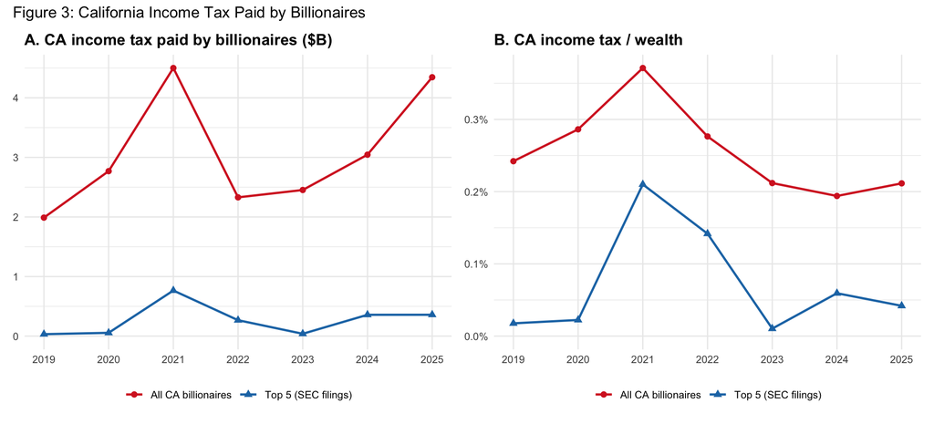

```r
tr("fig3")
```

**Table 3: tar_read(tab3_gt)**

```r
tr("tab3_gt")
```

Table 3. California Income Tax Paid by the Top 4 on Company Wealth

|  | Larry Page (Alphabet) | Sergei Brin (Alphabet) | Mark Zuckerberg (Meta) | Jensen Huang (Nvidia) | All top 4 |
| --- | --- | --- | --- | --- | --- |
| CA income tax 2019 | 0.00 | 0.00 | 26.40 | 6.19 | 32.59 |
| CA income tax 2020 | 0.00 | 0.00 | 34.89 | 20.29 | 55.18 |
| CA income tax 2021 | 240.55 | 167.59 | 298.58 | 58.88 | 765.60 |
| CA income tax 2022 | 120.26 | 83.93 | 2.52 | 60.50 | 267.21 |
| CA income tax 2023 | 0.00 | 0.00 | 11.26 | 27.85 | 39.11 |
| CA income tax 2024 | 82.92 | 54.15 | 165.99 | 54.85 | 357.91 |
| CA income tax 2025 | 87.07 | 56.25 | 125.98 | 89.39 | 358.69 |
| Average CA income tax 2019-2025 | 75.83 | 51.70 | 95.09 | 45.42 | 268.04 |
| Wealth at the beginning of 2019 | 41,576 | 40,085 | 47,768 | 2,857 | 132,286 |
| Wealth at end of 2025 | 244,240 | 225,401 | 225,635 | 160,228 | 855,503 |
| Total CA income tax / wealth gain 2019-2025 | 0.262% | 0.195% | 0.374% | 0.202% | 0.259% |

**Notes:** All amounts in nominal $M unless noted. CA income tax is computed from each billionaire’s SEC Form 4 filings (target `data_sec_top4`). Row 11 is the lifetime effective tax rate on the 2019-2025 wealth gain.

## B. All taxes paid by billionaires: Figure 4

**What is computed.** Figure 4 adds federal income tax, corporate tax and property and sales tax to the state income tax, each as a share of wealth. Corporate tax is attributed to billionaires in proportion to what they own. For private businesses, which file no public accounts, the workbook scales the public-company tax rate by the split of private wealth between pass-through and private C-corporations. August changed two of those weights and the gross-up for diversified holdings (11% in May, 9.5% in August); see RC2 below.

**Figure 4: tar_read(fig4)**

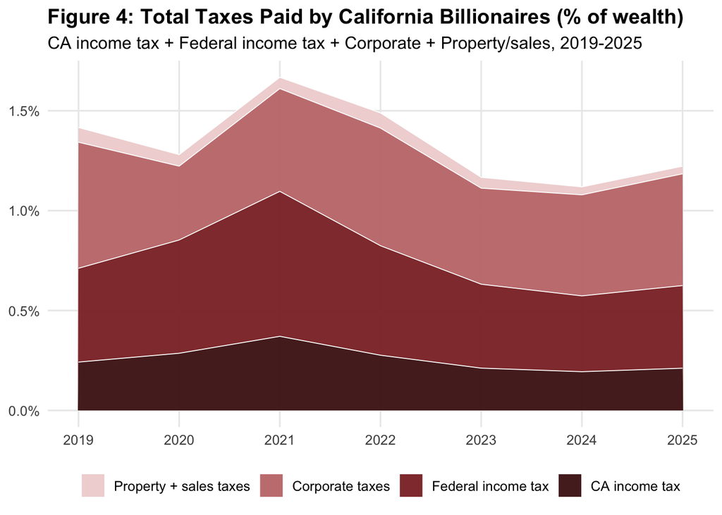

```r
tr("fig4")
```

## C. All taxes paid by the top 4: Table 4 and Figures 5 to 7

> Table 4 provides detailed numbers of wealth, income earned, and taxes paid by type of tax for the top 4 over the full 2019-2025 period. (BSZ PDF p.15)

**What is computed.** For the four largest fortunes the workbook builds taxes bottom up from company filings: each person’s share $s_{i,t}$ of company profits and corporate taxes,
$$\Pi_{i,t} = s_{i,t}\,\Pi_{\text{firm},t},$$
plus imputed property tax (1% of property, plant and equipment) and sales tax. “Economic income” adds retained company profits to the income that shows up on a tax return, because a founder’s share of profits the company keeps is income to them even though it is never taxed as such. Figure 5 compares taxes with fiscal income, economic income and wealth gains; Figure 6 runs the tax rates back to 2004; Figure 7 compares them with economy-wide averages.

**Table 4: tar_read(tab4_gt)**

```r
tr("tab4_gt")
```

Table 4. Wealth, Income, and Taxes of the Top 4, 2019-2025

|  | Total 2019-2025 ($B) | Annual average ($B) |
| --- | --- | --- |
| Wealth in 2019 (beginning of year) | 132.29 | — |
| Wealth in 2025 (end of year) | 855.50 | — |
| Gain in wealth during 2019-2025 | 723.22 | 103.32 |
| Wealth (average over 2019-2025) | — | 402.86 |
| Fiscal individual income | 18.44 | 2.63 |
| Stock-options exercise + non-equity comp | 2.32 | 0.33 |
| Dividends | 4.00 | 0.57 |
| Realized capital gains | 11.80 | 1.69 |
| Memo: Appreciated stock donated to charity | 17.37 | 2.48 |
| Memo: Net collateral pledged | 3.14 | 0.45 |
| Federal individual income tax | 3.62 | 0.52 |
| California individual income tax | 1.88 | 0.27 |
| Individual taxes / individual income | 29.8% | 29.8% |
| Corporate profits | 128.41 | 18.34 |
| Corporate taxes (federal) | 21.32 | 3.05 |
| Corporate tax rate (effective) | 16.6% | 16.6% |

**Notes:** All amounts in nominal $B. Source: per-billionaire SEC Form 4 filings aggregated as `data_sec_top4`’s “Total (excluding Ellison)” rows.

**Figure 5: tar_read(fig5)**

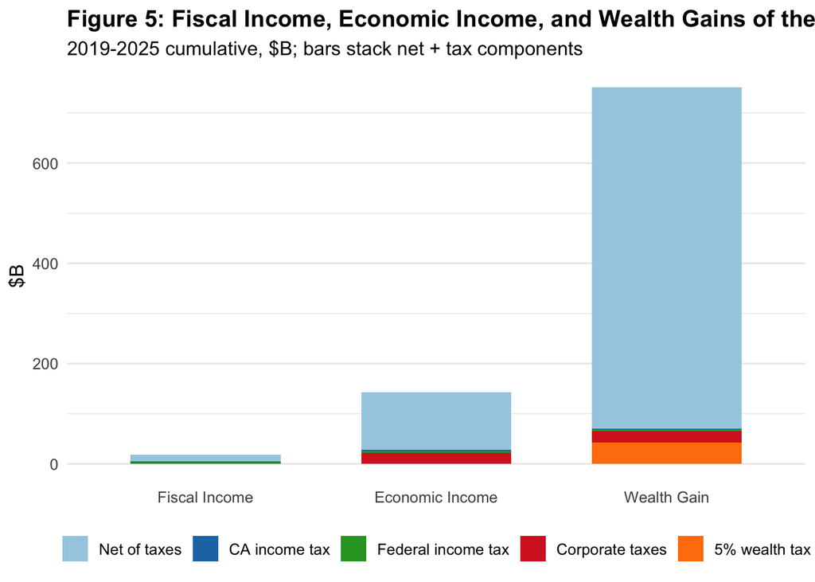

```r
tr("fig5")
```

**Figure 6: tar_read(fig6)**

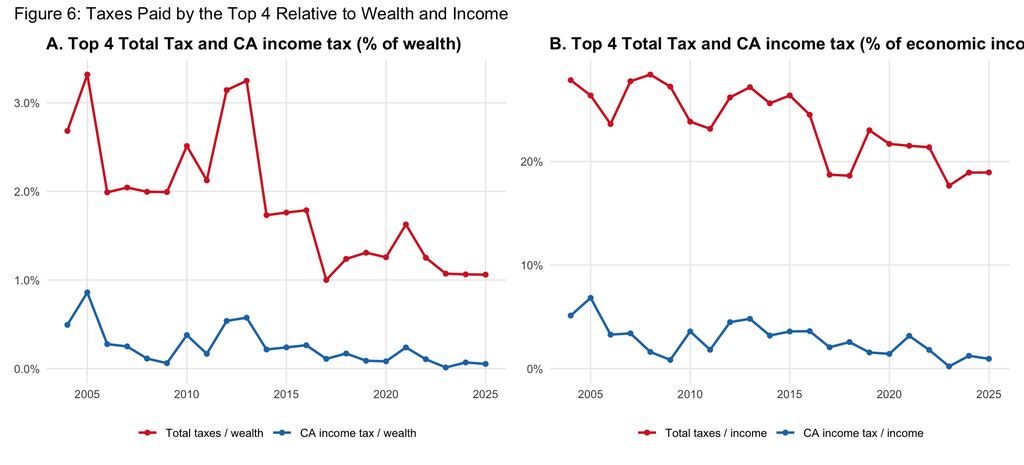

```r
tr("fig6")
```

**Figure 7: tar_read(fig7)**

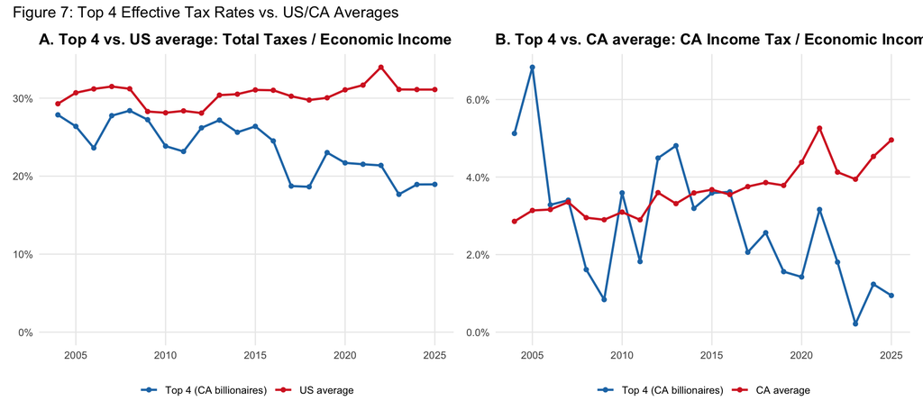

```r
tr("fig7")
```

# IV. The economics of taxing billionaires’ wealth

## A. The one-time 5% tax: Table 5, step by step

This is the section the supporting side’s headline rests on. Table 5 has four rows. Row 1 is the benchmark; rows 2 to 4 change one assumption at a time. We build row 1 in five steps, then each other row as a change to it.

### Step 1: the tax base

> Using the July 1st wealth value of $2.3 trillion, the wealth tax scores at $104 billion (=90%*5%*$2307 billion). (BSZ PDF p.24)

The base is Forbes’ real-time list on 1 July 2026: $n_0$ = 250 billionaires with $W_0$ = $2,307 billion. These two numbers are typed into the workbook (`Tab5!B6:C6`); they are data, but data the authors read off Forbes on that day, not something the pipeline recomputes. The Act itself values wealth on 31 December 2026, so the real base will differ; GGSS note that the daily score ranged from $87 billion to $107 billion between January and mid-July 2026 (GGSS p.4, fn.8).

### Step 3: wealth tax revenue

$$T = \tau\,W^{\text{tax}} = 0.05 \times 2,076.3 = 103.8.$$
That is the preferred estimate: $103.8 billion, collected once (in five annual installments). Before avoidance, 5% of the base would be $115.4 billion; avoidance costs $11.5 billion.

### Step 4: extra state income tax from selling assets

> Table 5 reports a column of this extra CA income tax generated assuming that wealth taxes will be paid one-third by selling assets triggering taxable realized capital gains (with a basis of 20% of selling price …) and two-thirds with liquidities or debt. (BSZ PDF p.24)

To pay the tax, some billionaires sell shares, and selling realises capital gains that the state taxes. With a share $s$ of the tax paid by selling, a share $g$ of each sale being gain, and the top state rate $t_{cg}$ on gains:
$$E = s \cdot g \cdot t_{cg} \cdot T = \tfrac13 \times 0.80 \times 0.133 \times 103.8 = 3.68.$$
So the tax pays back about 3.5% of itself in income tax, spread over the five payment years. The one-third is guesswork; the 80% gain share is the paper’s own estimate of how much of billionaire wealth is unrealised gains.

### Step 5: income tax lost to billionaires who leave

> If we assume that half of the 10% avoidance takes the form of mobility: i.e. 5% of billionaires were able to successfully relocate outside California in the narrow time window before January 1st, 2026, then we estimate that a corresponding 5% of the total California individual income tax paid by billionaires will be lost. (BSZ PDF p.24)

A billionaire who leaves stops paying California income tax. The authors assume half of the avoidance ($m$ = 50%) is people leaving, so $\alpha m$ = 5% of the income tax billionaires pay is lost:
$$L = -\alpha\,m\,C = -0.10 \times 0.5 \times 3.06 = -0.153 \text{ per year}.$$
This is a *yearly* loss, and Table 5 does not say for how many years. The paper argues that, for a genuinely one-time tax, departures should be temporary, “say only 5 years” (PDF p.27). The opposing side counts the loss forever. That difference in horizon is the largest single dispute between the two sides (`comparison/DISPUTES.md`, row 2) and is outside this side’s output.

### Row 2: adding the billionaires Forbes misses

> If we assume that the tail is Pareto with constant b=4.48 between $1 billion and $4.5 billion, then this means that there should be around 617 California billionaires (instead of the 249 listed by Forbes). (BSZ PDF p.25)

Above $4.5 billion, average wealth over any threshold is a steady multiple of the threshold, $b$ = 4.48: the signature of a Pareto distribution. Below $4.5 billion the Forbes list’s $b$ climbs towards 9, which is what a list missing many small fortunes looks like. Holding $b$ at 4.48 down to $1 billion adds 368 billionaires and $615 billion to the 15 April 2026 list the workbook used, that is 148% more people but only 28.2% more wealth. Row 2 applies those two percentages to the 1 July base, with a higher avoidance rate $\alpha_s$ = 20% for these less visible fortunes, and subtracts a deduction for those in the $1 to $1.1 billion band, where the Act phases the rate in:
$$T_2 = \tau\left[(1-\alpha)W_0 + (1-\alpha_s)\,\Delta W\right] - 0.025\,f_{ph}\,\Delta W, \qquad \Delta W = 28.2\% \times W_0,$$
with $f_{ph}$ = 12.1% the share of the added wealth in the phase-in band. The result is $127.9 billion.

**Appendix Figure A4: tar_read(fig_a4)**

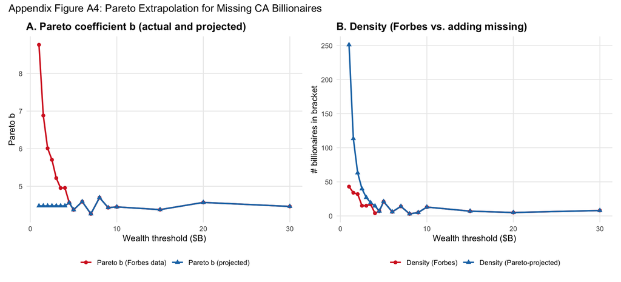

```r
tr("fig_a4")
```

### Row 3: an aggressive assumption on who has left

> The third row in Table 5 scores the wealth tax assuming that Page, Thiel, Hankey, Kalanick successfully moved before January 1, 2026 which is an aggressive assumption. (BSZ PDF p.26)

Two groups are treated differently. Four people are assumed to have left *before* 1 January 2026, so they escape the tax altogether and stop paying income tax. Three more (Brin, Zuckerberg, Fang) pay the tax but are assumed to leave later, so only their income tax is lost. For the top three, lost income tax on company wealth is their SEC-based average from Table 3; on everything else it is proportional to wealth, at the rate billionaires pay outside the top four’s company wealth, 0.201% of wealth a year (`Tab5!F18/B18`):

**the seven named leavers: tar_read(site_scoring_inputs)$leavers**

```r
lv <- inp$leavers
lv$name <- tools::toTitleCase(lv$name)
lv$wealth <- bn(lv$wealth)
lv$annual_inctax_loss <- bn(lv$annual_inctax_loss, 3)
names(lv) <- c("Person", "Assumed timing", "Wealth, $B", "Income tax lost, $B/yr")
show(lv)
```

| Person | Assumed timing | Wealth, $B | Income tax lost, $B/yr |
| --- | --- | --- | --- |
| Page | pre-2026 (escapes the wealth tax) | 294.6 | 0.103 |
| Thiel | pre-2026 (escapes the wealth tax) | 27.3 | 0.055 |
| Hankey | pre-2026 (escapes the wealth tax) | 8.2 | 0.016 |
| Kalanick | pre-2026 (escapes the wealth tax) | 3.6 | 0.007 |
| Brin | post-2026 (pays it, then leaves) | 271.7 | 0.078 |
| Zuckerberg | post-2026 (pays it, then leaves) | 210.3 | 0.100 |
| Fang | post-2026 (pays it, then leaves) | 1.5 | 0.003 |

Taxable wealth falls to $0.9\,(W_0 - W_{pre})$ with $W_{pre}$ = $333.6 billion, and revenue to $88.8 billion. The yearly income tax loss grows to $0.52 billion, still small, because the SEC data show the top three pay little income tax relative to their wealth. Whether any of these people has actually changed legal residence is a legal judgment, and the most important guesswork in the whole dispute (`comparison/DISPUTES.md`, row 3).

### Row 4: rows 2 and 3 together

Row 4 adds the Pareto billionaires to row 3: $114.8 billion, with a yearly income tax loss of $0.56 billion. One detail: row 4 does **not** subtract the phase-in deduction that row 2 subtracts for the same added billionaires (`Tab5!F9` against `Tab5!F7`). We reproduce the workbook as it is; a consistent treatment would lower row 4 by $2.0 billion. We list this under What reproduces.

### Table 5, reproduced

**Table 5: tar_read(tab5_gt)**

```r
tr("tab5_gt")
```

Table 5. Scoring the One-Time 5% California Wealth Tax

|  | # CA billionaires | Wealth ($B) | Taxable wealth ($B) | Avoidance rate | Wealth tax revenue ($B) | Extra CA inctax from sales ($B) | Annual CA inctax loss ($B) |
| --- | --- | --- | --- | --- | --- | --- | --- |
| 1. Benchmark: Forbes estimates + 10% avoidance | 250.0 | 2,307.0 | 2,076.3 | 10.0% | 103.8 | 3.7 | −0.2 |
| 2. Adding missing small billionaires (Pareto extrapolation) | 619.6 | 2,957.4 | 2,596.6 | 12.2% | 127.9 | 4.5 | −0.2 |
| 3. Aggressive assumptions for pre/post-2026 leavers | 250.0 | 2,307.0 | 1,776.1 | 23.0% | 88.8 | 3.1 | −0.5 |
| 4. Benchmark with both adding small billionaires and aggressive leavers | 619.6 | 2,957.4 | 2,296.3 | 22.4% | 114.8 | 4.1 | −0.6 |

**Notes:** Scenarios assume a one-time 5% wealth tax. Wealth tax revenue = taxable_wealth × 5%. Extra CA income tax from sales reflects forced asset sales to pay the tax (33% realization × 80% LTCG-taxable × 13.3% CA rate). Annual CA inctax loss is the steady-state revenue forgone from billionaires leaving California. Source: `tab5_r`.

**every Table 5 cell against the workbook’s cached value**

```r
xl <- read_sheet("Tab5", range = "B6:H9")
cols <- c("n_billionaires", "wealth", "taxable_wealth", "avoidance_rate",
          "wealth_tax_revenue", "extra_ca_inctax_sales", "annual_ca_inctax_loss")
dev <- abs(as.matrix(t5[, cols]) - as.matrix(xl))
t5_cells <- length(dev); t5_maxdev <- max(dev)
```

All 28 cells match the workbook’s cached values; the largest absolute difference is 1.4e-16.

**every Table 5 cell against the digit printed in the paper: tar_read(site_tab5_printed)**

```r
pr <- tr("site_tab5_printed")
miss <- pr[!pr$matches_printed, ]
miss_txt <- paste0("row ", miss$row, " (printed ", formatC(miss$printed, format = "f", digits = 2),
                   ", workbook ", formatC(miss$reproduced, format = "f", digits = 3), ")")
```

Matching the *printed* table is a stricter test, because the paper rounds. Of the 28 printed cells, 26 are what the reproduced value rounds to. The other 2 are both in the income tax loss column: row 2 (printed -0.19, workbook -0.196) and row 3 (printed -0.51, workbook -0.515). The workbook’s own cached values agree with ours, and the paper’s text quotes the printed figures ($0.19 billion on PDF p.25, $0.51 billion on p.26), so the paper rounds these two cells differently from its own workbook. Both are a cent of a billion; neither changes an argument.

### How far the guesses move the result

The explorer holds every combination of the six assumptions. Here each one moves on its own, with the others at row 1:

**one-at-a-time ranges from tar_read(site_grid)**

```r
dials <- site_dials()
keys  <- vapply(dials, `[[`, "", "key")
base  <- stats::setNames(mapply(function(d, j) d$levels[j], dials, site_named_rows()[[1]]), keys)
lvl   <- function(d, v) switch(d$fmt, pct = paste0(round(100 * v), "%"),
                               bool = if (v == 1) "yes" else "no",
                               frac3 = c("none", "1/3", "2/3", "all")[round(3 * v) + 1])
alone <- function(key) {   # grid cells where only `key` differs from row 1
  Reduce(`&`, lapply(setdiff(keys, key), function(k) abs(grid[[k]] - base[[k]]) < 1e-9))
}
rng <- do.call(rbind, lapply(dials, function(d) {
  g <- grid[alone(d$key), ]
  data.frame(
    input = d$label, origin = d$origin,
    tried = paste(lvl(d, min(d$levels)), "to", lvl(d, max(d$levels))),
    `revenue, $B` = paste(bn(min(g$wealth_tax_revenue)), "to", bn(max(g$wealth_tax_revenue))),
    `income tax lost, $B/yr` = paste(bn(-max(g$annual_ca_inctax_loss), 2), "to",
                                     bn(-min(g$annual_ca_inctax_loss), 2)),
    check.names = FALSE)
}))
show(rng)
```

| input | origin | tried | revenue, $B | income tax lost, $B/yr |
| --- | --- | --- | --- | --- |
| Avoidance and evasion | guesswork | 0% to 30% | 80.7 to 115.4 | 0.00 to 0.46 |
| Share of avoidance that is leaving | guesswork | 0% to 100% | 103.8 to 103.8 | 0.00 to 0.31 |
| Avoidance by the less visible billionaires | guesswork | 10% to 50% | 103.8 to 103.8 | 0.15 to 0.15 |
| Share of the tax paid by selling assets | guesswork | none to all | 103.8 to 103.8 | 0.15 to 0.15 |
| Count billionaires Forbes misses | research | no to yes | 103.8 to 127.9 | 0.15 to 0.20 |
| Aggressive assumption on leavers | guesswork | no to yes | 88.8 to 103.8 | 0.15 to 0.52 |

### Two documents, one number

**the GGSS figure is row 1, rounded**

```r
ggss_cited <- 100   # GGSS p.1 and p.4 (cited, not computed)
stopifnot(round(t5$wealth_tax_revenue[1]) == 104)
```

GGSS start from the same 250 people and $2,307 billion, take 5% ($115 billion), apply the same 10% avoidance and get $104 billion, which they round to $100 billion. The expert report’s other figures also come from BSZ Table 5: the $128 billion with missing billionaires (row 2, reproduced as $127.9 billion) and “about $20 billion/year” (one fifth of the rounded total, the annual installment).

## B. A permanent annual wealth tax: the Laffer curve

This part scores a different policy, a wealth tax charged every year, which is not what Proposition 40 proposes. The paper uses it to answer the argument that billionaires will leave for fear of future taxes. The pipeline’s “Figure 8” is the August paper’s Figure 9 (August inserted a new Figure 8 on venture capital, which the pipeline does not build).

> With a semi-elasticity e, the wealth tax rate that maximizes tax revenue while taking into account mobility responses is τ=1/e. (BSZ PDF p.28)

**What is computed.** A semi-elasticity $e$ says each extra percentage point of tax shrinks the base by about $e$ percent through people moving away. With a base of $Z_0$ = $2,000 billion at today’s tax (the workbook’s rounded input) and $\tau_0$ = 0.2% of wealth, the income tax billionaires already pay,
$$Z(\tau) = Z_0\, e^{-e(\tau - \tau_0)}, \qquad T(\tau) = \tau\, Z(\tau).$$
Revenue peaks where the next point of tax loses as much base as it gains in rate, at $\tau = 1/e$. With $e$ = 10 (Brülhart et al. 2022, the same value Rauh et al. use) that is 10%. The long-run curve also erodes wealth itself: $d$ = 15 years of paying the tax shrinks fortunes by $(1-\tau)^d$, and revenue then peaks at 3.9%, close to the paper’s $1/(1+d+e) = 3.8\%$.

**the Laffer curve (August Figure 9): tar_read(fig8)**

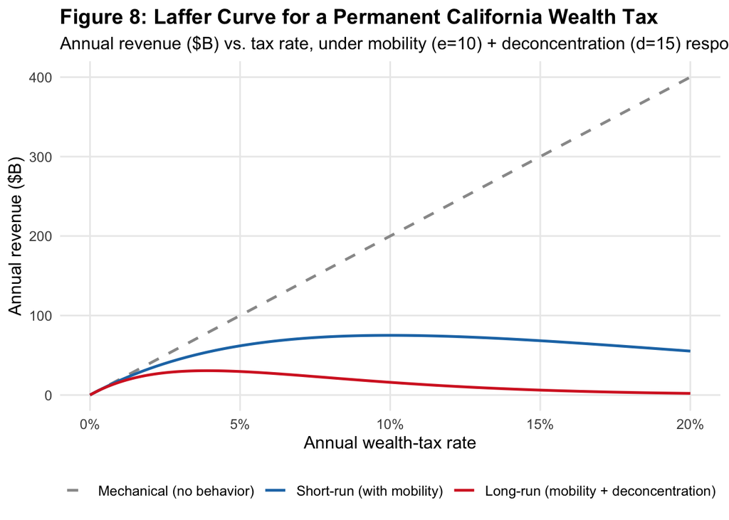

```r
tr("fig8")
```

# Appendix exhibits

## Appendix Table A1: US billionaires

**Appendix Table A1: tar_read(tab_a1_gt)**

```r
tr("tab_a1_gt")
```

Appendix Table A1. Wealth Growth of US Billionaires

| Year | # / families | Wealth | Growth / per family | # US families (M) | US GDP | GDP / family ($) |
| --- | --- | --- | --- | --- | --- | --- |
| A. Recent nominal wealth growth of US billionaires |  |  |  |  |  |  |
| 2022 | 717 | 4,358 | — | — | 14,752 | 0 |
| 2023 | 746 | 5,247 | 20.4% | — | 15,128 | 0 |
| 2024 | 813 | 6,723 | 28.1% | — | 16,457 | 0 |
| 2025 | 938 | 8,189 | 21.8% | — | 17,280 | 0 |
| 2026 | 982 | 8,826 | 15.6% | — | 18,144 | 0 |
| Growth during 3 years (2023-2025) | — | 1 | — | — | 0 | — |
| B. Long-term real wealth growth: top .001% wealthiest US families (2026 $) |  |  |  |  |  |  |
| 1982 | 1,105 | 459 | 41.5% | 111 | 6,127 | 55,437 |
| 2026 | 1,950 | 10,570 | 542.0% | 195 | 18,144 | 93,050 |
| Ratio 2025 to 1982 | 2 | 23 | 1,305.4% | 2 | 3 | 2 |
| Annualized growth | 0 | 0 | 6.0% | 0 | 0 | 0 |

**Notes:** Repeats Tab 1 for US billionaires instead of CA. Panel A: nominal wealth of all US citizen billionaires (Forbes). Panel B: 1982 vs 2025 real wealth of top .0002% US families, in 2025 dollars.

## Appendix Figures A2 and A3

**Appendix Figure A2: tar_read(fig_a2)**

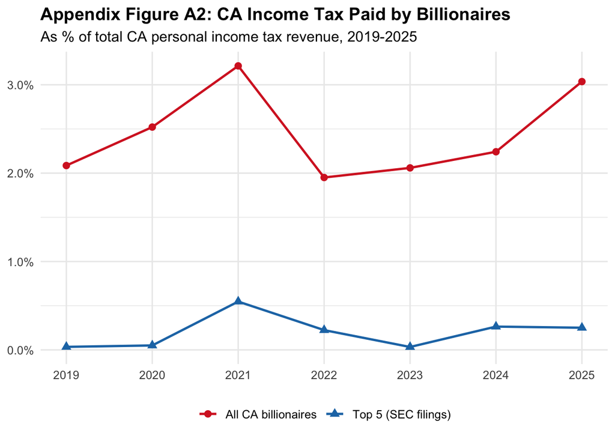

```r
tr("fig_a2")
```

**Appendix Figure A3: tar_read(fig_a3)**

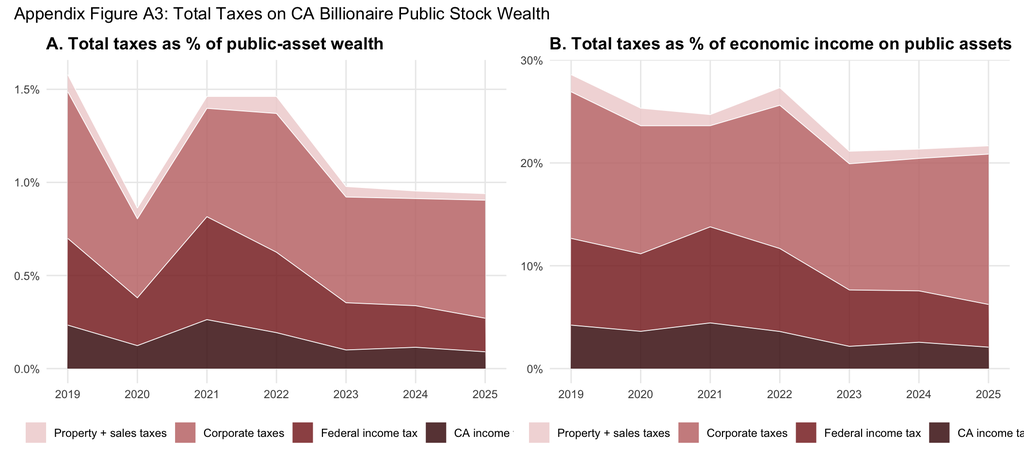

```r
tr("fig_a3")
```

# Every input, by origin

This section is not in the paper. It sorts every input of the one-time scoring by how much evidence stands behind it, which is the first question a reader who wants to argue with the result has to answer.

- **data**: read off a public source, and in principle re-collectable from it.
- **research**: an estimate from a published study, including the authors’ own.
- **guesswork**: set by assumption; argued for, but not measured.
- **scenario**: a choice about which policy is being scored.
- **derived**: implied by other rows. **convention**: a date.

**every input: tar_read(site_inputs)**

```r
show(ins)
```

| symbol | input | value | origin | basis |
| --- | --- | --- | --- | --- |
| τ | Wealth tax rate | 5% one-time | scenario | The Act as written: 5%, payable 1%/yr over 5 years (GGSS p.1). |
| W₀ | Wealth of CA billionaires, 1 Jul 2026 | $2,307 B | data | Forbes real-time list, 7/1/2026 (Tab5!C6; BSZ PDF p.24). |
| n₀ | Number of CA billionaires, 1 Jul 2026 | 250 | data | Forbes real-time list, 7/1/2026 (Tab5!B6). |
| α | Avoidance and evasion | 10% | guesswork | Asserted, argued from enforcement (GGSS p.4; BSZ PDF p.23). Explorer dial. |
| m | Share of avoidance that is leaving | 50% | guesswork | Asserted (BSZ PDF p.24; Tab5 row 1 label). Explorer dial. |
| αₛ | Avoidance, less visible billionaires | 20% | guesswork | Asserted (BSZ PDF p.25). Explorer dial. |
| s | Share of the tax paid by selling assets | 1/3 | guesswork | Asserted (BSZ PDF p.24). Explorer dial. |
| L | Who left before 1 Jan 2026 (Table 5 rows 3 and 4) | no one (row 1) | guesswork | A legal judgment on residency; rows 3-4 assume Page, Thiel, Hankey, Kalanick (BSZ PDF p.26). Explorer dial. |
| g | Capital-gain share of a sale | 80% | research | BSZ's own estimate that CA billionaire wealth is 80% unrealized gains (PDF p.24). |
| t_cg | Top CA income tax rate on gains | 13.3% | data | California statute, top marginal rate (Tab5!G6). |
| C | CA income tax paid by billionaires, 2019-2025 average | $3.06 B/yr | research | BSZ's own FTB + Pareto estimate (Tab2!C14; Table 2 of the paper), reproduced in this pipeline. |
| b | Pareto coefficient above $4.5B | 4.48 | research | Estimated from Forbes 4/15/2026 (Pareto-missing sheet; BSZ PDF p.25). |
| ΔW_P | Wealth added by the Pareto extrapolation | +28.2% | research | Pareto-missing!I23, derived from b. |
| Δn_P | Billionaires added by the Pareto extrapolation | +148% | research | Pareto-missing!J23, derived from b. |
| f_ph | Share of added wealth in the $1B-1.1B phase-in | 12.1% | derived | Pareto-missing!I24, derived from b. |
| W_pre | Wealth of pre-2026 leavers (Page, Thiel, Hankey, Kalanick) | $333.6 B | data | Forbes 7/1/2026 values typed into Tab5!B20:B23. |
| L_lv | Annual CA income tax of all seven named leavers | $0.36 B/yr | derived | Top-3 company income tax from SEC data (Tab3 row 13) plus a wealth-proportional rate on the rest (Tab5!F19+F24). |
| date | Valuation date | 1 Jul 2026 | convention | The Act values wealth at 31 Dec 2026; BSZ and GGSS score on the latest Forbes snapshot. |

**how many of each kind**

```r
cnt <- as.data.frame(table(factor(ins$origin,
  levels = c("data", "research", "guesswork", "scenario", "derived", "convention"))))
names(cnt) <- c("origin", "inputs")
show(cnt)
```

| origin | inputs |
| --- | --- |
| data | 4 |
| research | 5 |
| guesswork | 5 |
| scenario | 1 |
| derived | 2 |
| convention | 1 |

**how many of each kind**

```r
# Which guesses move the headline revenue? Vary each dial alone around row 1.
moves_rev <- vapply(dials, function(d) diff(range(grid$wealth_tax_revenue[alone(d$key)])) > 1e-9, TRUE)
is_guess  <- vapply(dials, `[[`, "", "origin") == "guesswork"
guess_moving_rev <- vapply(dials[moves_rev & is_guess], `[[`, "", "label")
n_guess_dials <- sum(is_guess)
stopifnot(sum(ins$origin == "guesswork") == n_guess_dials)
```

**The headline.** Of the 18 inputs, 5 are guesswork, and they are exactly the explorer’s 5 guesswork dials. Only 2 of them move the revenue number when varied on their own (avoidance and evasion; aggressive assumption on leavers); the others move only the smaller income tax columns, or matter only in the scenario rows. So the preferred $103.8 billion is Forbes’ list, times 5%, times one minus a single guessed avoidance rate; the only other guess that moves it is who has already left. The disputes with the opposing side are mostly about inputs this table labels guesswork or scenario: who has left (row 3), how long losses last, and whether a one-time tax triggers permanent departures.

# What reproduces

**test results, from site/data/test-results.csv**

```r
tests <- read.csv("data/test-results.csv", stringsAsFactors = FALSE)
by_file <- aggregate(cbind(blocks = 1, passed, failed) ~ file, data = tests, FUN = sum)
show(rbind(by_file, data.frame(file = "total", blocks = sum(by_file$blocks),
                               passed = sum(by_file$passed), failed = sum(by_file$failed))))
```

| file | blocks | passed | failed |
| --- | --- | --- | --- |
| test-compute.R | 9 | 215 | 0 |
| test-data_sheets.R | 9 | 45 | 0 |
| test-figures.R | 22 | 76 | 0 |
| test-ingest_excel.R | 5 | 20 | 0 |
| test-site.R | 6 | 40 | 0 |
| test-snapshots.R | 28 | 34 | 0 |
| test-tables.R | 14 | 121 | 0 |
| test-verify.R | 6 | 7 | 0 |
| total | 99 | 558 | 0 |

The suite ran on 2026-09-23 against the august workbook: 558 expectations passed and 0 failed. The `compute`, `tables` and `data_sheets` files compare R against the workbook’s own cached cells, formula by formula, at a stated tolerance; `snapshots` pins every output so any change fails; `site` pins the explorer to the reproduction. Figures are checked for structure and a few anchor values, not pixel by pixel.

## Mismatches found, and how each was resolved

The August workbook was first run through code written for the May version, and 184 expectations failed. Every failure was traced to one of ten root causes before anything was fixed (`VERIFY-AUGUST.md`):

| Cause | What it was | Resolution |
| --- | --- | --- |
| RC1 | `shortrunseries`: August moved most columns and dropped one | column map per vintage (`R/vintage.R`) |
| RC2 | `billionairesCAinctax`: two rows inserted; the diversified-holdings gross-up changed from 11% to 9.5% and two private-wealth weights changed | row map per vintage; new parameters ported |
| RC3 | Table 5’s typed-in base and leaver wealth moved to the 1 July 2026 Forbes values | constants per vintage |
| RC4 | Table 1 and A1 denominators changed from GDP to AGI | ported from the formulas |
| RC5 | a “2026 (July 1st)” row inserted in Tables 1 and A1 | ported |
| RC6 | Panel B redefined from the top .0002% to the top .001%, endpoint 2025 to 2026 | ported |
| RC7 | Table 2 gained two columns; its average row changed formula | ported |
| RC8 | the Laffer sheet moved from `Fig8` to `Fig9` | sheet name per vintage |
| RC9 | four smaller literals (row counts, a sheet count, one cell) | updated |
| RC10 | a genuine data error in the workbook, below | de-duplicated |

**A data-entry error in the workbook.** In August’s `data_sec_all` sheet, rows 1338 to 1341 (four 2025 entries: Sijbrandij, Rihanna, Preston-Werner, Stephens) appear a second time at rows 1342 to 1345. Counting both copies gives 244 billionaires; dropping the repeat gives 240, which matches the workbook’s own aggregate sheet and the paper’s text. The pipeline drops rows that repeat year, person and wealth exactly (`R/compute_data_sec_agg.R`).

**Two printed cells that differ from the workbook.** Table 5’s income tax loss in rows 2 and 3 is printed as $0.19 and $0.51 billion; the workbook, and this reproduction, give values that round to $0.20 and $0.52 (see Table 5, reproduced).

**Readings the workbook leaves implicit.** Both are kept at the workbook’s behaviour and disclosed on the explorer:

- `Tab5!H6` types the income tax loss share as a literal 0.05. We read it as avoidance times the leaving share (0.10 × 0.5), as the row label says. It matters only when the explorer moves those inputs.
- Row 4 omits row 2’s phase-in deduction (`Tab5!F9`), worth $2.0 billion.

**Display labels that lag the data.** Tables 1 and A1 hold August values under some May labels (GDP for AGI, 2025 for 2026, .0002% for .001%, 2025 dollars for 2026 dollars), and a few summary cells render as rounded zeros. The numbers are tested; the labels are not. Fixing them changes the pinned table snapshots, so it is left for a separate change.

**What is not reproduced.**

- August’s new Figure 8 (venture capital deals) and new Appendix Figure A1 (wealth relative to AGI) have no builder yet.
- The raw inputs are not re-collected (Forbes, Franchise Tax Board, SEC, IRS, national accounts), except a one-person SEC proof of concept. An error in the workbook’s inputs would pass straight through.
- The GGSS July report has no workbook of its own. Its $100 billion is reproduced only in the sense above: it is BSZ row 1, rounded.

## Reproducing this document

```bash
cd supporting-analysis
Rscript -e 'targets::tar_make(names = !tidyselect::any_of(c("report_html","report_pdf")))'
Rscript tools/site-test-results.R      # writes site/data/test-results.csv
cd site && quarto render repro.qmd
```

The workbook is not redistributed; `DATA-SOURCES.csv` gives its URL and SHA-256. Set `CAWTBSZ_MATERIALS` if it lives outside `supporting-analysis/original-materials/`.

Supporting side of California Proposition 40: Open Output (the explorer) · Open Analysis: Report (here) and Slides · Open Materials · Overview